# Data Wrangling 3: Time Series Data and Missing Values

# Load Packages

```r
library(dplyr)
library(tidyr)

# Specify package preferences for filter, count, select, and arrange
library(conflicted)
conflict_prefer("filter", "dplyr", quiet = TRUE)
conflict_prefer("count", "dplyr", quiet = TRUE)
conflict_prefer("select", "dplyr", quiet = TRUE)
conflict_prefer("arrange", "dplyr", quiet = TRUE)
```

# Import Weather Data

First, we import some weather data from the CIMIS network that has been saved to a [Google Sheet](https://docs.google.com/spreadsheets/d/13FR4Mji24KqZmLqK_BiLKew8nN4MbCdh1KpzT54hH4M/) that can be viewed by anyone with the link.

```r
library(googlesheets4)
arvinedison_url <- "https://docs.google.com/spreadsheets/d/13FR4Mji24KqZmLqK_BiLKew8nN4MbCdh1KpzT54hH4M/"

## Tell R not to authorize with Google (not needed for this public Google Sheet)
gs4_deauth()

arvinedison_tbl <- read_sheet(arvinedison_url, sheet = "Sheet1")
```

```
✔ Reading from Arvin-Edison CIMIS Data Sep-2023.
✔ Range ''Sheet1''.
```

```r
## View(arvinedison_tbl)
head(arvinedison_tbl)
```

| Name | Type | Owner | Year | Month | Day | Julian | Station | Standard | ZipCodes | Scope | Item | Value | Qc | Unit |
| --- | --- | --- | --- | --- | --- | --- | --- | --- | --- | --- | --- | --- | --- | --- |
| cimis | station | water.ca.gov | 2023 | 9 | 16 | 259 | 125 | english | 93203 | daily | DayAirTmpMax | 94.20 | NA | (F) |
| cimis | station | water.ca.gov | 2023 | 9 | 16 | 259 | 125 | english | 93203 | daily | DayAirTmpMin | 64.30 | NA | (F) |
| cimis | station | water.ca.gov | 2023 | 9 | 16 | 259 | 125 | english | 93203 | daily | DayEto | 0.21 | NA | (in) |
| cimis | station | water.ca.gov | 2023 | 9 | 16 | 259 | 125 | english | 93203 | daily | DayAsceEto | 0.21 | NA | (in) |
| cimis | station | water.ca.gov | 2023 | 9 | 16 | 259 | 125 | english | 93203 | daily | DayPrecip | 0.00 | NA | (in) |
| cimis | station | water.ca.gov | 2023 | 9 | 17 | 260 | 125 | english | 93203 | daily | DayAirTmpMax | 86.30 | NA | (F) |

**Pro Tip:**

You can download data from the CIMIS network directly into R using the [`cimir`](https://cran.r-project.org/package=cimir) package (Michael Koohafkan).

```
library(cimir)
set_key("xxxxxxxx-xxxx-xxxx-xxxx-xxxxxxxxxxxx")
arvinedison_tbl <- cimis_data(targets = 125, start.date = "2023-09-16", end.date = "2023-10-15",
                               items = "day-air-tmp-max,day-air-tmp-min,day-eto,day-precip")
```

# CHALLENGE #1

Would you consider the CIMIS data to be long or wide?

It is tidy?

# Create a date column

```r
library(lubridate)
arvedsn_dt_tbl <- arvinedison_tbl |>
  mutate(Dt = make_date(year = Year, month = Month, day = Day)) |>
  relocate(Dt, .after = Day)

## View(arvedsn_dt_tbl)
head(arvedsn_dt_tbl)
```

| Name | Type | Owner | Year | Month | Day | Dt | Julian | Station | Standard | ZipCodes | Scope | Item | Value | Qc | Unit |
| --- | --- | --- | --- | --- | --- | --- | --- | --- | --- | --- | --- | --- | --- | --- | --- |
| cimis | station | water.ca.gov | 2023 | 9 | 16 | 2023-09-16 | 259 | 125 | english | 93203 | daily | DayAirTmpMax | 94.20 | NA | (F) |
| cimis | station | water.ca.gov | 2023 | 9 | 16 | 2023-09-16 | 259 | 125 | english | 93203 | daily | DayAirTmpMin | 64.30 | NA | (F) |
| cimis | station | water.ca.gov | 2023 | 9 | 16 | 2023-09-16 | 259 | 125 | english | 93203 | daily | DayEto | 0.21 | NA | (in) |
| cimis | station | water.ca.gov | 2023 | 9 | 16 | 2023-09-16 | 259 | 125 | english | 93203 | daily | DayAsceEto | 0.21 | NA | (in) |
| cimis | station | water.ca.gov | 2023 | 9 | 16 | 2023-09-16 | 259 | 125 | english | 93203 | daily | DayPrecip | 0.00 | NA | (in) |
| cimis | station | water.ca.gov | 2023 | 9 | 17 | 2023-09-17 | 260 | 125 | english | 93203 | daily | DayAirTmpMax | 86.30 | NA | (F) |

# Create a wide version of the table

Guide to pivoting: https://tidyr.tidyverse.org/articles/pivot.html

```r
library(tidyr)
arvedsn_wide_tbl <- arvedsn_dt_tbl |>
  pivot_wider(names_from = Item, values_from = Value, id_cols = c(Station, Dt))

## View(arvedsn_wide_tbl)
head(arvedsn_wide_tbl)
```

| Station | Dt | DayAirTmpMax | DayAirTmpMin | DayEto | DayAsceEto | DayPrecip |
| --- | --- | --- | --- | --- | --- | --- |
| 125 | 2023-09-16 | 94.2 | 64.3 | 0.21 | 0.21 | 0.00 |
| 125 | 2023-09-17 | 86.3 | 61.6 | 0.19 | 0.18 | 0.00 |
| 125 | 2023-09-18 | 83.5 | 66.2 | 0.20 | 0.19 | 0.00 |
| 125 | 2023-09-19 | 84.2 | 62.0 | 0.18 | 0.17 | 0.00 |
| 125 | 2023-09-20 | 86.8 | 61.6 | 0.19 | 0.18 | 0.00 |
| 125 | 2023-09-21 | 78.2 | 55.6 | 0.18 | 0.17 | 0.09 |

# Deal with Missing Values

The evapotranspiration column has some missing values. In this section, we’ll look at a couple of different methods of filling them in. (For a real project, we’d want to consult someone who knows about evapotranspiration to decide which method is most appropriate for these data!)

First, we create a data frame with just Eto:

```r
arvedsn_eto_tbl <- arvedsn_dt_tbl |>
  filter(Item == "DayEto") |>
  select(Station, Dt, Item, Value, Unit)

head(arvedsn_eto_tbl)
```

| Station | Dt | Item | Value | Unit |
| --- | --- | --- | --- | --- |
| 125 | 2023-09-16 | DayEto | 0.21 | (in) |
| 125 | 2023-09-17 | DayEto | 0.19 | (in) |
| 125 | 2023-09-18 | DayEto | 0.20 | (in) |
| 125 | 2023-09-19 | DayEto | 0.18 | (in) |
| 125 | 2023-09-20 | DayEto | 0.19 | (in) |
| 125 | 2023-09-21 | DayEto | 0.18 | (in) |

Are there missing values?

```r
## View(arvedsn_eto_tbl)

summary(arvedsn_eto_tbl)
```

```
    Station          Dt                 Item               Value            Unit
 Min.   :125   Min.   :2023-09-16   Length:30          Min.   :0.1000   Length:30
 1st Qu.:125   1st Qu.:2023-09-23   Class :character   1st Qu.:0.1500   Class :character
 Median :125   Median :2023-09-30   Mode  :character   Median :0.1800   Mode  :character
 Mean   :125   Mean   :2023-09-30                      Mean   :0.1708
 3rd Qu.:125   3rd Qu.:2023-10-07                      3rd Qu.:0.1900
 Max.   :125   Max.   :2023-10-15                      Max.   :0.2100
                                                       NA's   :5
```

# Fix #1. Throw away incomplete rows

`tidyr::drop_na()` will throw away rows that have `NA` values in *any* of the specified columns (default is check all columns):

```r
arvedsn_eto_fix1_tbl <- arvedsn_eto_tbl |>
  tidyr::drop_na()

# View(arvedsn_eto_fix1_tbl)
nrow(arvedsn_eto_tbl); nrow(arvedsn_eto_fix1_tbl)
```

```
[1] 30
[1] 25
```

# Fix #2. Replace with the mean or median

Step 1. Decide: mean or median?

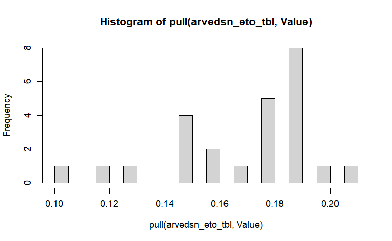

```r
arvedsn_eto_tbl |> pull(Value) |> hist(breaks = 20)
```

Step 2. Compute the median

```r
value_median <- arvedsn_eto_tbl |> pull(Value) |> median(na.rm = TRUE)
value_median
```

```
[1] 0.18
```

Step 3. Substitute the median whenever `Value` is NA.

```r
arvedsn_eto_fix2_tbl <- arvedsn_eto_tbl |>
  mutate(Value_Fix1 = if_else(is.na(Value), value_median, Value))

## You can also use tidyr::replace_na()
## arvedsn_eto_fix2_tbl <- arvedsn_eto_tbl |>
##   replace_na(list(Value = value_median))

# View(arvedsn_eto_fix2_tbl)
```

# Fix #3. Interpolate missing values

To interpolate missing values, we’ll create a vector with the replacement values (using the `zoo` package), and then tack it on to the data frame.

First, create the replacement values:

```r
library(zoo)
vals_linear_interpolation <- na.approx(arvedsn_eto_tbl$Value)
vals_linear_interpolation
```

```
 [1] 0.2100 0.1900 0.2000 0.1800 0.1900 0.1800 0.1900 0.1900 0.1900 0.1800 0.1825 0.1850 0.1875 0.1900 0.1300 0.1200 0.1600 0.1700 0.1800
[20] 0.1900 0.1800 0.1900 0.1800 0.1700 0.1600 0.1000 0.1500 0.1500 0.1500 0.1500
```

```r
# You can also do spline interpolation
# vals_spline_interpolation <- na.spline(arvedsn_eto_tbl$Value)
# vals_spline_interpolation
```

Next, add the vector with imputed values as a new column with `bind_cols`:

```r
arvedsn_eto_fix2_tbl <- arvedsn_eto_tbl |>
  bind_cols(Value_Fix2 = vals_linear_interpolation)

# View(arvedsn_eto_fix3_tbl)
head(arvedsn_eto_fix2_tbl)
```

| Station | Dt | Item | Value | Unit | Value_Fix2 |
| --- | --- | --- | --- | --- | --- |
| 125 | 2023-09-16 | DayEto | 0.21 | (in) | 0.21 |
| 125 | 2023-09-17 | DayEto | 0.19 | (in) | 0.19 |
| 125 | 2023-09-18 | DayEto | 0.20 | (in) | 0.20 |
| 125 | 2023-09-19 | DayEto | 0.18 | (in) | 0.18 |
| 125 | 2023-09-20 | DayEto | 0.19 | (in) | 0.19 |
| 125 | 2023-09-21 | DayEto | 0.18 | (in) | 0.18 |

This is just scratching the surface of dealing with missing values!

See also: [imputeTS](https://steffenmoritz.github.io/imputeTS/)

# CHALLENGE #2

There are also some missing values in the Maximum Daily Air Temperature (DayAirTmpMax).

Decide what would be a reasonable method to deal with these, and implement it.

# Resampling data

Bin the Eto values into low, medium, and high:

```r
arvedsn_eto_fix3_tbl <- arvedsn_eto_fix2_tbl |>
  mutate(eto_level = case_when(Value_Fix2 <= 0.14 ~ "low",
                               Value_Fix2 <= 0.19 ~ "medium",
                               TRUE ~ "high"))

# View(arvedsn_eto_fix3_tbl)
head(arvedsn_eto_fix3_tbl)
```

| Station | Dt | Item | Value | Unit | Value_Fix2 | eto_level |
| --- | --- | --- | --- | --- | --- | --- |
| 125 | 2023-09-16 | DayEto | 0.21 | (in) | 0.21 | high |
| 125 | 2023-09-17 | DayEto | 0.19 | (in) | 0.19 | medium |
| 125 | 2023-09-18 | DayEto | 0.20 | (in) | 0.20 | high |
| 125 | 2023-09-19 | DayEto | 0.18 | (in) | 0.18 | medium |
| 125 | 2023-09-20 | DayEto | 0.19 | (in) | 0.19 | medium |
| 125 | 2023-09-21 | DayEto | 0.18 | (in) | 0.18 | medium |

# End

Remember to save your work to render a HTML file.